# Maps and Polarization: 50 states (MTurk)

Adrienne Wood

7/15/2022

# Overview of experiment

## Purpose

In this experiment, we expand on the first political map experiment. The aim of the first experiment was to test whether presenting electoral maps using a continuous vs a dichotomous gradient decreased participants’ estimates of political polarization. In addition to testing the gradients, we tested whether using a novel color scheme (orange/green) vs the typical color scheme (red/blue) decreased polarization estimates. In this initial study, we found that when people have salient associations between groups and colors (red-Republican and blue-Democrat), continuous gradient maps decrease predicted voting polarization, but when there are no prior conditioned associations (green-Democrat, orange-Republican) the dichotomization of colors has no significant effect on predicted polarization. For this second experiment, our aim is to test whether these findings hold when participants are presented with the real electoral outcomes of a previous election (2020 Presidential Election). Additionally, instead of constraining the states to swing states, we are randomly assigning 15/50 states to each participant with the actual results of the 2020 election depicted in one of four ways:  
* Dichotomous red/blue * Continuous red/blue * Dichotomous orange/green * Continuous orange/green Each color depicted on a state represents the winning party’s majority for that particular state.

## Design

Participants are asked 2 key dependent variables on each of the 15 trials:  
**1) Percent voting Democrat** “Click on the scale below and move the slider to the percentage of people you think voted for Joe Biden (Democratic candidate) and Donald Trump (Republican candidate) in the particular US State (initialed below and represented on the map) during the 2020 Presidential Election.” Participants are shown a slider scale which depicts the percentage ratio assigned to democrat vs republican on the scale.  
We’ll first take the 2020 returns and convert them into percent voting Democratic out of those voters who didn’t vote third party (to remove the third party votes). We’ll then subtract these state-level values from participants’ estimates of the percent that voted Democratic. More positive responses means they overestimated how many Democrat votes there were and negative means they underestimated Democrat votes. We want the scores to reflect how much they overestimated the state that actually won-i.e., how polarized their estimates were-so we’ll reverse score the states that went Republican (e.g., LA, ND, OK, FL) by multiplying by -1. The resulting values will be our Polarization outcome variable.

**2) Influence** “Imagine you were a resident of that particular State - How influential would your vote have been in that election?”1 Not influential at all – 5 Extremely Influential”

## Inclusion criteria

We preregistered the plan to exclude the following participants: - Participants admit to looking up electoral results on google - Participants fail to correctly select California on the attention check map. - Participants fail to identify the correct states on each trial

# Data preparation

```r
dQ <-read.csv("map_study2b_mturk_50states_cleanedqualtrics.csv",check.names = FALSE) # Qualtrics data
questionKey <-read.csv("question_key.csv",check.names = FALSE)
electionResults <-read.csv("2020_election_results.csv",check.names = FALSE)

# pivot the wide data into long format separately for our two DVs, influence and percent Dem.
dQInfluence <-pivot_longer(dQ,cols=contains("Influ"),names_to="InfquestionID",values_to="influence")
dQPD <-pivot_longer(dQ,cols=contains("_11"),names_to="PDquestionID",values_to="percentDemocrat")

# Then join these together. CAUTION: IF THE DATAFILE HAS CHANGED, the hard-coded column numbers may break.
dLong <-cbind(dQInfluence[,c(1:7,608:629)],dQPD[,c("PDquestionID","percentDemocrat")])

# We have a ton of rows where our DV columns are blank because participants were only shown a subset
# of the questions. So remove those blanks.
dLong <-dLong[!is.na(dLong$percentDemocrat),]

# Match the data with details about which condition and state each row represents.
dLong$question_label <-dLong$PDquestionID
dLong2 <- join(dLong,questionKey,by=c("question_label"),type="left")

# Match the data with 2020 election results
d <-join(dLong2,electionResults,by=c("state"),type="left")


# Remove the 53 participant who failed the California attention check.
length(unique(d[d$"attention-check"!="Like","ResponseId"]))
```

```
## [1] 53
```

```r
d <-d[d$"attention-check"=="Like",]

# Remove 18 additional people who said they got outside help (there were 63 before removing attention check fails)
length(unique(d[d$"cheated"!="No","ResponseId"]))
```

```
## [1] 18
```

```r
d <- d[d$cheated=="No",]

# Convert "percent democrat" scores to "response polarization" scores
d$votingDifference <-d$percentDemocrat-d$portion_dem
d$responsePolarization <-ifelse(d$called=="r",d$votingDifference*(-1),d$votingDifference)

# Recode the likert items for "influence" to be numeric
d$influenceS <-d$influence
d<-d%>% mutate(influence=recode(influenceS,"Not at all influential"=1,"Slightly influential"=2,"Moderately influential"=3,
                                        "Very influential"=4,"Extremely influential"=5))

# Center our predictors for analyses
d$colorC <-ifelse(d$color=="OG",-.5,.5)
d$gradientC <-ifelse(d$gradient=="continuous",-.5, .5)

# Create a "margin" variable that represents how polarized the state actually was (absolute value)
d$margin <-abs(d$portion_dem-50)
```

# Descriptives

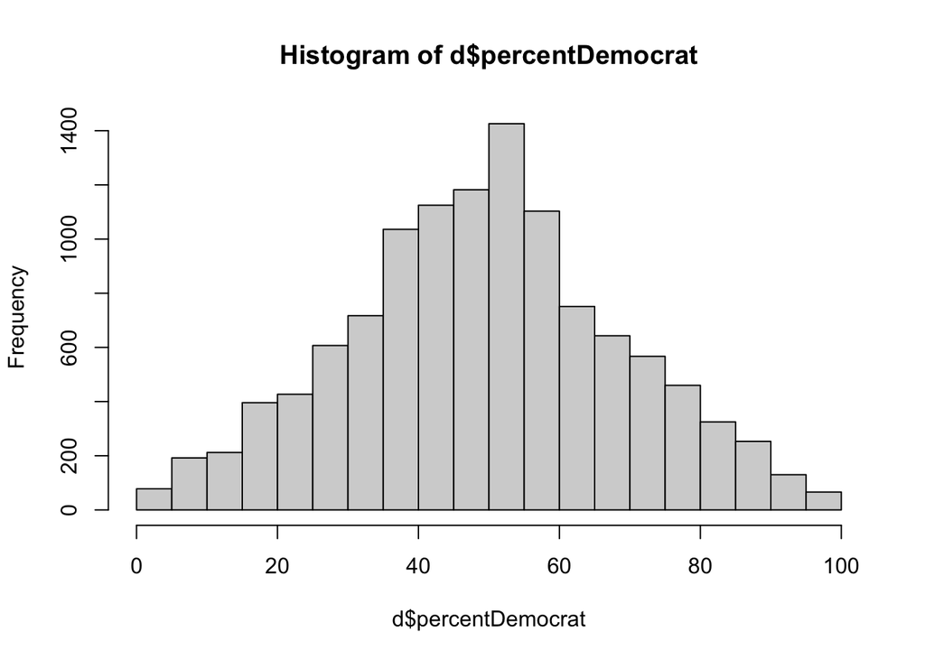

```r
# Look at distribution of raw responses
hist(d$percentDemocrat)
```

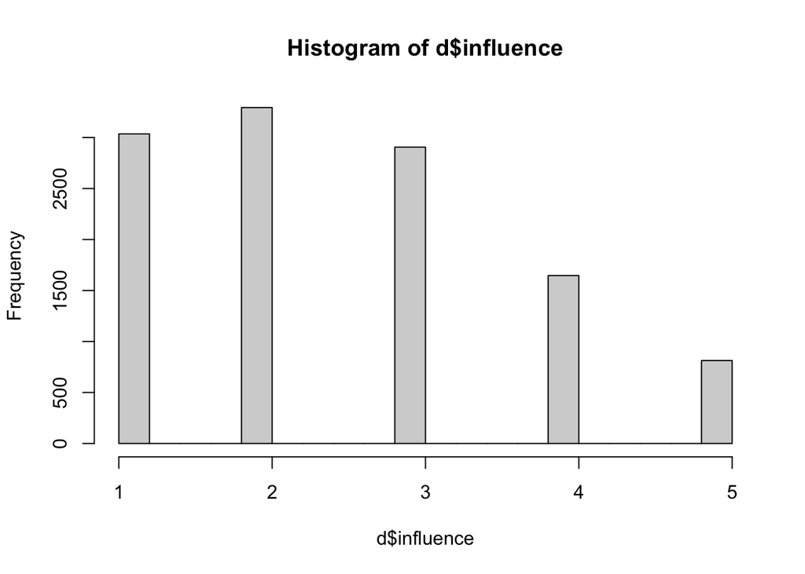

```r
hist(d$influence)
```

```r
# breakdown of number of participants in each condition
dP <-aggregate(d$responsePolarization,by=list("ResponseId"=d$ResponseId,"color"=d$color,"gradient"=d$gradient),FUN="mean")
dP2 <-aggregate(dP[,"ResponseId"],by=list(dP$color,dP$gradient),FUN="length")
dP2
```

```
##   Group.1     Group.2   x
## 1      OG  continuous 193
## 2      RB  continuous 195
## 3      OG dichotomous 196
## 4      RB dichotomous 196
```

```r
# demographics
dD <-aggregate(d$responsePolarization,by=list("ResponseId"=d$ResponseId,"color"=d$color,"gradient"=d$gradient, "gender"=d$gender,"ethnicity"=d$ethnicity,"education"=d$degree_earned,"candidate"=d$candidate_voted_for,"registration"=d$registration, "age"=d$age),FUN="mean")

table(dD$gender)
```

```
##
##              Female                Male Other (write it in)  Transgender female
##                 393                 380                   3                   2
##    Transgender male
##                   2
```

```r
table(dD$ethnicity)
```

```
##
## Asian/Pacific Islander Black/African American      Hispanic/Latino/a
##                     50                     83                     46
##        Native American                  Other        White/Caucasian
##                      5                     19                    577
```

```r
table(dD$education)
```

```
##
##      2-year college degree      4-year college degree
##                        105                        342
##         High school degree      Less than high school
##                        183                          4
##            Master's degree PhD or Professional degree
##                        115                         31
```

```r
table(dD$candidate)
```

```
##
##   Donald Trump I did not vote      Joe Biden
##            205            145            430
```

```r
table(dD$registration)
```

```
##
##                                                           Democrat
##                                                                325
##                                        I am not registered to vote
##                                                                 43
## I am registered to vote, but not affiliated with a political party
##                                                                112
##                                                        Independent
##                                                                136
##                            Other (If other, please write in party)
##                                                                  4
##                                                         Republican
##                                                                160
```

```r
table(dD$age)
```

```
##
## 18-24 25-34 35-44 45-54 55-59 60-64 65-74 75-84
##    47   262   223   139    38    37    32     2
```

# Main analyses

## Percent voting Democrat estimate DV

```r
d$marginC <-d$margin-mean(d$margin)
modPolarization <-lmer(responsePolarization~gradientC*colorC+(1|ResponseId)+(1|state),data=d)
summary(modPolarization)
```

```
## Linear mixed model fit by REML. t-tests use Satterthwaite's method [
## lmerModLmerTest]
## Formula: responsePolarization ~ gradientC * colorC + (1 | ResponseId) +
##     (1 | state)
##    Data: d
##
## REML criterion at convergence: 92801.7
##
## Scaled residuals:
##     Min      1Q  Median      3Q     Max
## -6.6413 -0.3925  0.0046  0.4958  4.7995
##
## Random effects:
##  Groups     Name        Variance Std.Dev.
##  ResponseId (Intercept)  58.69    7.661
##  state      (Intercept)   9.28    3.046
##  Residual               141.73   11.905
## Number of obs: 11696, groups:  ResponseId, 780; state, 50
##
## Fixed effects:
##                   Estimate Std. Error        df t value Pr(>|t|)
## (Intercept)        3.41747    0.52250  92.00641   6.541 3.39e-09 ***
## gradientC          2.17620    0.59130 775.72263   3.680 0.000249 ***
## colorC             0.07877    0.59126 775.52648   0.133 0.894057
## gradientC:colorC   0.12346    1.18252 775.50426   0.104 0.916878
## ---
## Signif. codes:  0 '***' 0.001 '**' 0.01 '*' 0.05 '.' 0.1 ' ' 1
##
## Correlation of Fixed Effects:
##             (Intr) grdntC colorC
## gradientC   -0.003
## colorC      -0.001  0.003
## grdntC:clrC  0.001 -0.003 -0.005
```

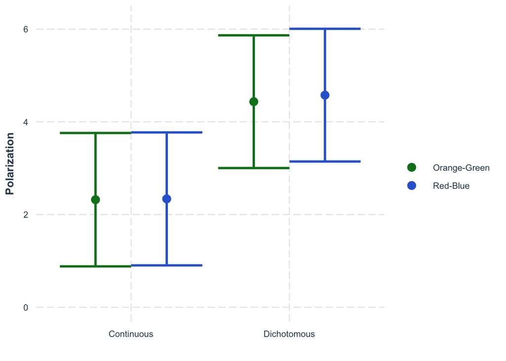

```r
modPolarizationGraph <-lmer(responsePolarization~gradient*color+(1|ResponseId)+(1|state),data=d)
pol_plot <-cat_plot(modPolarizationGraph,modx=color,pred=gradient,modx.labels=c("Orange-Green","Red-Blue"),pred.labels=c("Continuous","Dichotomous"),y.label="Polarization",x.label="",interval=TRUE,legend.main="",colors=c("#077F21","#3267D2"))
pol_plot+ ylim(c(0,6.2))
```

```r
ggsave("polarization-study2-2-wayinteraction.png",height=5,width=4)
```

We will also check the simple effects. First, the effect of gradient for red-blue maps. The main effect for gradient tells us how “gradient” influenced judgments for red-blue maps.

```r
d$ColorRB <-d$colorC -.5
modRB <-lmer(responsePolarization~gradientC*ColorRB+(1|ResponseId)+(1|state),data=d)
summary(modRB)
```

```
## Linear mixed model fit by REML. t-tests use Satterthwaite's method [
## lmerModLmerTest]
## Formula: responsePolarization ~ gradientC * ColorRB + (1 | ResponseId) +
##     (1 | state)
##    Data: d
##
## REML criterion at convergence: 92801.7
##
## Scaled residuals:
##     Min      1Q  Median      3Q     Max
## -6.6413 -0.3925  0.0046  0.4958  4.7995
##
## Random effects:
##  Groups     Name        Variance Std.Dev.
##  ResponseId (Intercept)  58.69    7.661
##  state      (Intercept)   9.28    3.046
##  Residual               141.73   11.905
## Number of obs: 11696, groups:  ResponseId, 780; state, 50
##
## Fixed effects:
##                    Estimate Std. Error        df t value Pr(>|t|)
## (Intercept)         3.45686    0.59996 154.33594   5.762 4.38e-08 ***
## gradientC           2.23793    0.83507 775.44553   2.680  0.00752 **
## ColorRB             0.07877    0.59126 775.52648   0.133  0.89406
## gradientC:ColorRB   0.12346    1.18252 775.50426   0.104  0.91688
## ---
## Signif. codes:  0 '***' 0.001 '**' 0.01 '*' 0.05 '.' 0.1 ' ' 1
##
## Correlation of Fixed Effects:
##             (Intr) grdntC ColrRB
## gradientC   -0.002
## ColorRB      0.491 -0.002
## grdntC:ClRB -0.001  0.706 -0.005
```

Then the effect of gradient for green-orange maps.

```r
d$ColorGO <-d$colorC+.5
modGO <-lmer(responsePolarization~gradientC*ColorGO+(1|ResponseId)+(1|state),data=d)
summary(modGO)
```

```
## Linear mixed model fit by REML. t-tests use Satterthwaite's method [
## lmerModLmerTest]
## Formula: responsePolarization ~ gradientC * ColorGO + (1 | ResponseId) +
##     (1 | state)
##    Data: d
##
## REML criterion at convergence: 92801.7
##
## Scaled residuals:
##     Min      1Q  Median      3Q     Max
## -6.6413 -0.3925  0.0046  0.4958  4.7995
##
## Random effects:
##  Groups     Name        Variance Std.Dev.
##  ResponseId (Intercept)  58.69    7.661
##  state      (Intercept)   9.28    3.046
##  Residual               141.73   11.905
## Number of obs: 11696, groups:  ResponseId, 780; state, 50
##
## Fixed effects:
##                    Estimate Std. Error        df t value Pr(>|t|)
## (Intercept)         3.37809    0.60071 155.03607   5.624  8.5e-08 ***
## gradientC           2.11447    0.83733 775.78049   2.525   0.0118 *
## ColorGO             0.07877    0.59126 775.52648   0.133   0.8941
## gradientC:ColorGO   0.12346    1.18252 775.50426   0.104   0.9169
## ---
## Signif. codes:  0 '***' 0.001 '**' 0.01 '*' 0.05 '.' 0.1 ' ' 1
##
## Correlation of Fixed Effects:
##             (Intr) grdntC ColrGO
## gradientC   -0.005
## ColorGO     -0.493  0.005
## grdntC:ClGO  0.004 -0.708 -0.005
```

## Influence DV

We will follow the same analytic procedure for predicting participants’ judgments of how influential their vote would be in each state. We preregistered that since this dependent variable is ordinal (a Likert scale), we’d use the ordinal package in r to fit a cumulative link mixed model (https://cran.r-project.org/web/packages/ordinal/vignettes/clmm2_tutorial.pdf). I’m having trouble getting this to work, so for now, we are using regular LMEMs.

```r
modInfluence <-lmer(influence~gradientC*colorC+ (1|ResponseId)+(1|state),data=d)
summary(modInfluence)
```

```
## Linear mixed model fit by REML. t-tests use Satterthwaite's method [
## lmerModLmerTest]
## Formula: influence ~ gradientC * colorC + (1 | ResponseId) + (1 | state)
##    Data: d
##
## REML criterion at convergence: 32911.7
##
## Scaled residuals:
##     Min      1Q  Median      3Q     Max
## -4.1852 -0.6483 -0.0493  0.6061  3.5520
##
## Random effects:
##  Groups     Name        Variance Std.Dev.
##  ResponseId (Intercept) 0.4782   0.6915
##  state      (Intercept) 0.1656   0.4069
##  Residual               0.8249   0.9082
## Number of obs: 11696, groups:  ResponseId, 780; state, 50
##
## Fixed effects:
##                   Estimate Std. Error        df t value Pr(>|t|)
## (Intercept)        2.48120    0.06320  68.06922  39.256  < 2e-16 ***
## gradientC         -0.17937    0.05230 776.22872  -3.429 0.000637 ***
## colorC             0.05861    0.05230 776.07562   1.121 0.262802
## gradientC:colorC  -0.09459    0.10460 776.05827  -0.904 0.366105
## ---
## Signif. codes:  0 '***' 0.001 '**' 0.01 '*' 0.05 '.' 0.1 ' ' 1
##
## Correlation of Fixed Effects:
##             (Intr) grdntC colorC
## gradientC   -0.002
## colorC      -0.001  0.003
## grdntC:clrC  0.001 -0.003 -0.005
```

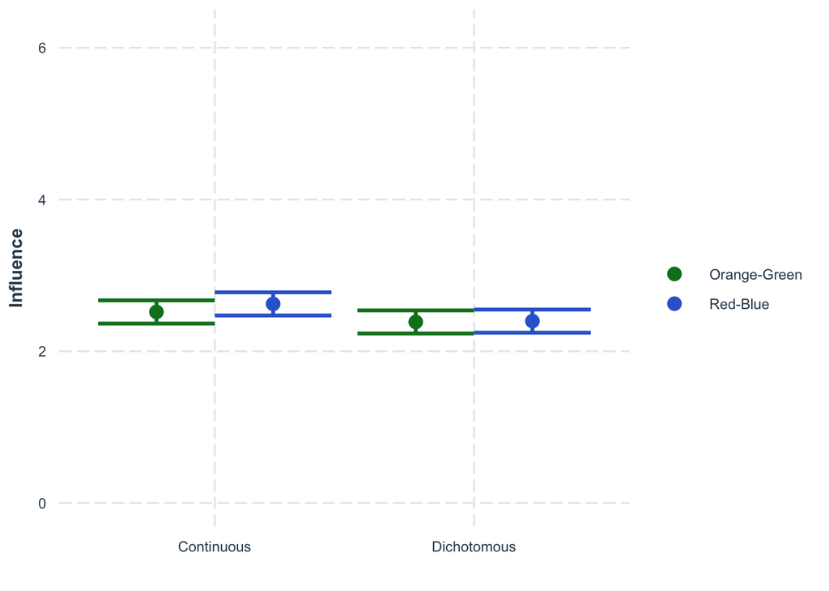

```r
modInfluenceGraph <-lmer(influence~gradient*color+(1|ResponseId)+(1|state),data=d)
inf_plot <-cat_plot(modInfluenceGraph,modx=color,pred=gradient,modx.labels=c("Orange-Green","Red-Blue"),pred.labels=c("Continuous","Dichotomous"),y.label="Influence",x.label="",interval=TRUE,legend.main="",colors=c("#077F21","#3267D2"))
inf_plot + ylim(c(0,6.2))
```

```r
ggsave("influence-study2-2-wayinteraction.png",height=5,width=4)
```

We will also check the simple effects. First, the effect of gradient for red-blue maps. The main effect for gradient tells us how “gradient” influenced judgments for red-blue maps.

```r
d$ColorRB <-d$colorC -.5
modRBInfluence <-lmer(influence~gradientC*ColorRB+(1|ResponseId)+(1|state),data=d)
summary(modRBInfluence)
```

```
## Linear mixed model fit by REML. t-tests use Satterthwaite's method [
## lmerModLmerTest]
## Formula: influence ~ gradientC * ColorRB + (1 | ResponseId) + (1 | state)
##    Data: d
##
## REML criterion at convergence: 32911.7
##
## Scaled residuals:
##     Min      1Q  Median      3Q     Max
## -4.1852 -0.6483 -0.0493  0.6061  3.5520
##
## Random effects:
##  Groups     Name        Variance Std.Dev.
##  ResponseId (Intercept) 0.4782   0.6915
##  state      (Intercept) 0.1656   0.4069
##  Residual               0.8249   0.9082
## Number of obs: 11696, groups:  ResponseId, 780; state, 50
##
## Fixed effects:
##                    Estimate Std. Error        df t value Pr(>|t|)
## (Intercept)         2.51050    0.06838  92.50982  36.717  < 2e-16 ***
## gradientC          -0.22667    0.07387 776.01238  -3.069  0.00223 **
## ColorRB             0.05861    0.05230 776.07562   1.121  0.26280
## gradientC:ColorRB  -0.09459    0.10460 776.05827  -0.904  0.36610
## ---
## Signif. codes:  0 '***' 0.001 '**' 0.01 '*' 0.05 '.' 0.1 ' ' 1
##
## Correlation of Fixed Effects:
##             (Intr) grdntC ColrRB
## gradientC   -0.001
## ColorRB      0.381 -0.002
## grdntC:ClRB -0.001  0.706 -0.005
```

Then the effect of gradient for green-orange maps.

```r
d$ColorGO <-d$colorC+.5
modGOInfluence <-lmer(influence~gradientC*ColorGO+(1|ResponseId)+(1|state),data=d)
summary(modGOInfluence)
```

```
## Linear mixed model fit by REML. t-tests use Satterthwaite's method [
## lmerModLmerTest]
## Formula: influence ~ gradientC * ColorGO + (1 | ResponseId) + (1 | state)
##    Data: d
##
## REML criterion at convergence: 32911.7
##
## Scaled residuals:
##     Min      1Q  Median      3Q     Max
## -4.1852 -0.6483 -0.0493  0.6061  3.5520
##
## Random effects:
##  Groups     Name        Variance Std.Dev.
##  ResponseId (Intercept) 0.4782   0.6915
##  state      (Intercept) 0.1656   0.4069
##  Residual               0.8249   0.9082
## Number of obs: 11696, groups:  ResponseId, 780; state, 50
##
## Fixed effects:
##                    Estimate Std. Error        df t value Pr(>|t|)
## (Intercept)         2.45189    0.06843  92.77996  35.832   <2e-16 ***
## gradientC          -0.13207    0.07406 776.27395  -1.783   0.0749 .
## ColorGO             0.05861    0.05230 776.07562   1.121   0.2628
## gradientC:ColorGO  -0.09459    0.10460 776.05827  -0.904   0.3661
## ---
## Signif. codes:  0 '***' 0.001 '**' 0.01 '*' 0.05 '.' 0.1 ' ' 1
##
## Correlation of Fixed Effects:
##             (Intr) grdntC ColrGO
## gradientC   -0.004
## ColorGO     -0.383  0.005
## grdntC:ClGO  0.003 -0.708 -0.005
```

# Actual voting margin as moderator

The effect of gradient on polarization might be stronger depending on where you are in the color gradient. So we’ll include that as a moderator.

## Polarization with Margin as moderator

```r
modPolarizationMargin <-lmer(responsePolarization~gradientC*colorC*marginC+(1|ResponseId)+(1|state),data=d)
summary(modPolarizationMargin)
```

```
## Linear mixed model fit by REML. t-tests use Satterthwaite's method [
## lmerModLmerTest]
## Formula:
## responsePolarization ~ gradientC * colorC * marginC + (1 | ResponseId) +
##     (1 | state)
##    Data: d
##
## REML criterion at convergence: 92570.9
##
## Scaled residuals:
##     Min      1Q  Median      3Q     Max
## -6.6052 -0.3802  0.0098  0.4919  4.7149
##
## Random effects:
##  Groups     Name        Variance Std.Dev.
##  ResponseId (Intercept)  59.132   7.69
##  state      (Intercept)   5.618   2.37
##  Residual               138.852  11.78
## Number of obs: 11696, groups:  ResponseId, 780; state, 50
##
## Fixed effects:
##                            Estimate Std. Error         df t value Pr(>|t|)
## (Intercept)               3.397e+00  4.473e-01  1.195e+02   7.594 7.57e-12 ***
## gradientC                 2.179e+00  5.924e-01  7.756e+02   3.679 0.000251 ***
## colorC                    5.512e-02  5.924e-01  7.755e+02   0.093 0.925879
## marginC                  -3.389e-01  6.175e-02  4.779e+01  -5.488 1.52e-06 ***
## gradientC:colorC          1.796e-01  1.185e+00  7.754e+02   0.152 0.879568
## gradientC:marginC        -5.792e-01  3.866e-02  1.099e+04 -14.980  < 2e-16 ***
## colorC:marginC            4.575e-02  3.865e-02  1.099e+04   1.184 0.236607
## gradientC:colorC:marginC -6.909e-02  7.729e-02  1.099e+04  -0.894 0.371385
## ---
## Signif. codes:  0 '***' 0.001 '**' 0.01 '*' 0.05 '.' 0.1 ' ' 1
##
## Correlation of Fixed Effects:
##             (Intr) grdntC colorC margnC grdntC:cC grdntC:mC clrC:C
## gradientC   -0.003
## colorC      -0.002  0.003
## marginC      0.004  0.000 -0.001
## grdntC:clrC  0.002 -0.003 -0.005  0.001
## grdntC:mrgC  0.001  0.000  0.003  0.004 -0.003
## colrC:mrgnC -0.002  0.003  0.000  0.001  0.002    -0.014
## grdntC:cC:C  0.002 -0.003  0.002 -0.005  0.000     0.002     0.014
```

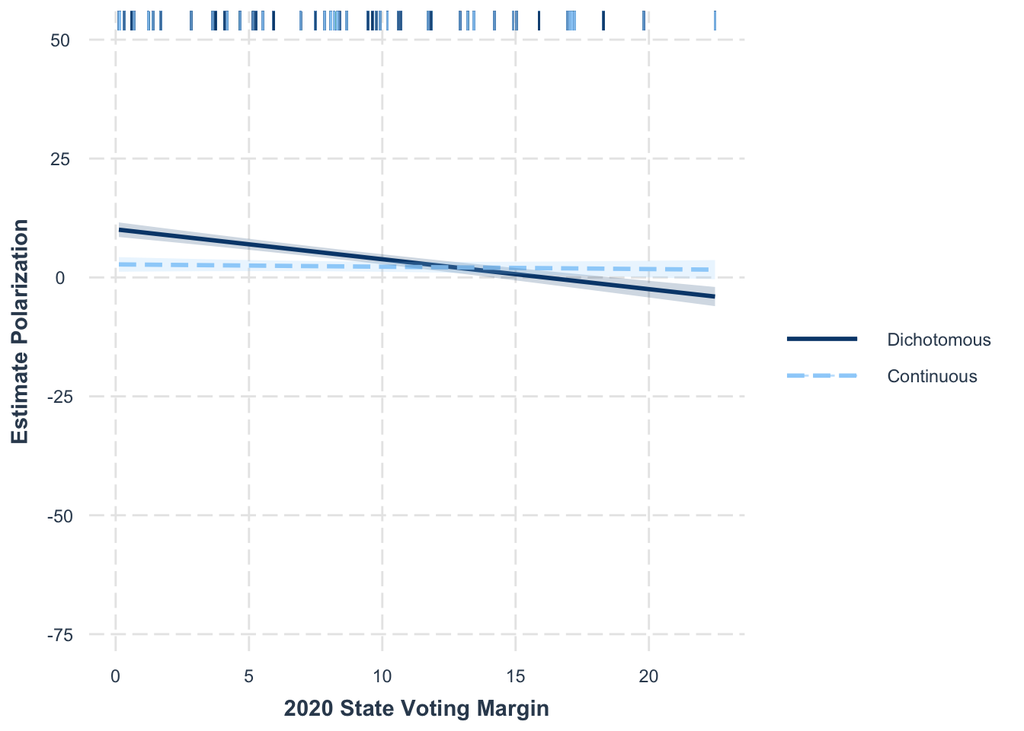

```r
modPolarizationMarginGraph<-lmer(responsePolarization~gradientC*colorC*margin+(1|ResponseId)+(1|state),data=d)

# graphs without points
interact_plot(modPolarizationMarginGraph,pred=margin,modx=gradientC,legend.main="",x.label="2020 State Voting Margin", y.label="Estimate Polarization",modx.labels=c("Continuous","Dichotomous"),interval=TRUE,rug=TRUE,rug.sides = "t")
```

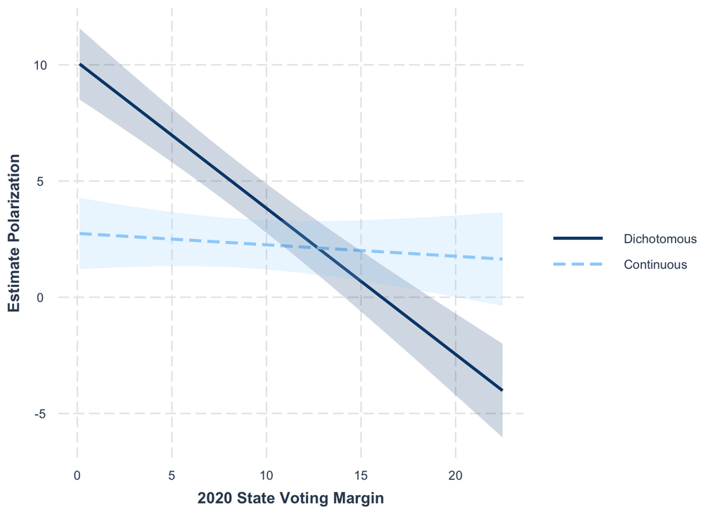

```r
ggsave("study2-margin-graph-with-rug.png")
interact_plot(modPolarizationMarginGraph,pred=margin,modx=gradientC,legend.main="",x.label="2020 State Voting Margin", y.label="Estimate Polarization",modx.labels=c("Continuous","Dichotomous"),interval=TRUE)
```

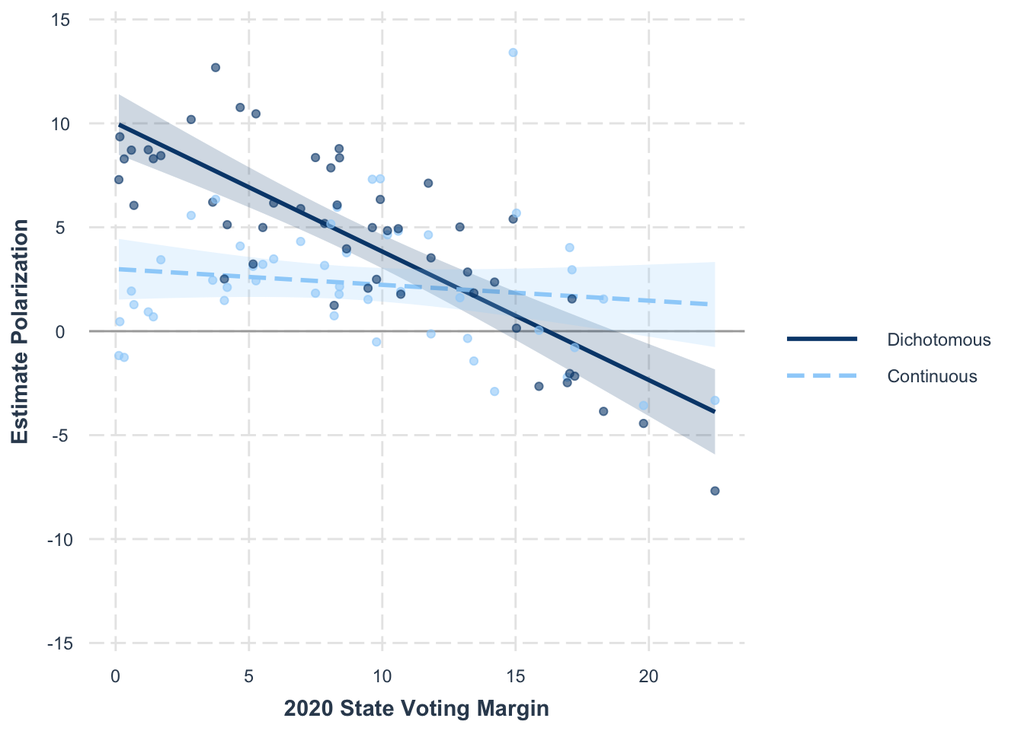

```r
ggsave("study2-margin-graph.png")
# graph with points
dStates <-aggregate(d[,c("responsePolarization","influence")],by=list("state"=d$state,"gradientC"=d$gradientC,"margin"=d$margin),FUN="mean")

modPolarizationMarginGraphPts<-lmer(responsePolarization~gradientC*margin+(1|state),data=dStates)
plot <-interact_plot(modPolarizationMarginGraphPts,pred=margin,modx=gradientC,legend.main="",x.label="2020 State Voting Margin", plot.points = TRUE, y.label="Estimate Polarization",modx.labels=c("Continuous","Dichotomous"),interval=TRUE)+ ylim(-14, 14)

plot$layers <-c(geom_hline(yintercept=0,color="dark grey"), plot$layers)
plot
```

```r
ggsave("study2-margin-graph-with-points.png")
```

## Influence with Margin as moderator

```r
modInfluenceMargin <-lmer(influence~gradientC*colorC*marginC+(1|ResponseId)+(1|state),data=d)
summary(modInfluenceMargin)
```

```
## Linear mixed model fit by REML. t-tests use Satterthwaite's method [
## lmerModLmerTest]
## Formula: influence ~ gradientC * colorC * marginC + (1 | ResponseId) +
##     (1 | state)
##    Data: d
##
## REML criterion at convergence: 32798.8
##
## Scaled residuals:
##     Min      1Q  Median      3Q     Max
## -3.9795 -0.6463 -0.0451  0.5992  3.6647
##
## Random effects:
##  Groups     Name        Variance Std.Dev.
##  ResponseId (Intercept) 0.47764  0.6911
##  state      (Intercept) 0.05097  0.2258
##  Residual               0.81820  0.9045
## Number of obs: 11696, groups:  ResponseId, 780; state, 50
##
## Fixed effects:
##                            Estimate Std. Error         df t value Pr(>|t|)
## (Intercept)               2.479e+00  4.126e-02  1.136e+02  60.096  < 2e-16 ***
## gradientC                -1.796e-01  5.225e-02  7.762e+02  -3.436 0.000621 ***
## colorC                    5.985e-02  5.225e-02  7.760e+02   1.145 0.252419
## marginC                  -5.860e-02  5.780e-03  4.788e+01 -10.138 1.66e-13 ***
## gradientC:colorC         -9.686e-02  1.045e-01  7.760e+02  -0.927 0.354266
## gradientC:marginC         2.822e-02  2.970e-03  1.096e+04   9.499  < 2e-16 ***
## colorC:marginC            1.483e-03  2.969e-03  1.096e+04   0.499 0.617613
## gradientC:colorC:marginC -9.934e-03  5.938e-03  1.096e+04  -1.673 0.094344 .
## ---
## Signif. codes:  0 '***' 0.001 '**' 0.01 '*' 0.05 '.' 0.1 ' ' 1
##
## Correlation of Fixed Effects:
##             (Intr) grdntC colorC margnC grdntC:cC grdntC:mC clrC:C
## gradientC   -0.003
## colorC      -0.002  0.003
## marginC      0.005  0.000 -0.001
## grdntC:clrC  0.002 -0.003 -0.005  0.001
## grdntC:mrgC  0.001  0.000  0.002  0.004 -0.003
## colrC:mrgnC -0.002  0.002  0.000  0.001  0.001    -0.014
## grdntC:cC:C  0.002 -0.003  0.001 -0.004  0.000     0.002     0.014
```

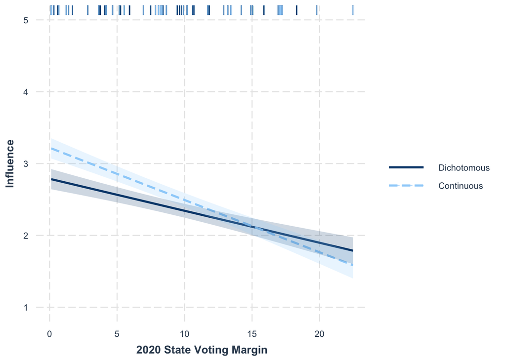

```r
modInfluenceMarginGraph <-lmer(influence~gradientC*colorC*margin+(1|ResponseId)+(1|state),data=d)


# graphs without points
interact_plot(modInfluenceMarginGraph,pred=margin,modx=gradientC,legend.main="",x.label="2020 State Voting Margin", y.label="Influence",modx.labels=c("Continuous","Dichotomous"),interval=TRUE,rug=TRUE,rug.sides = "t")
```

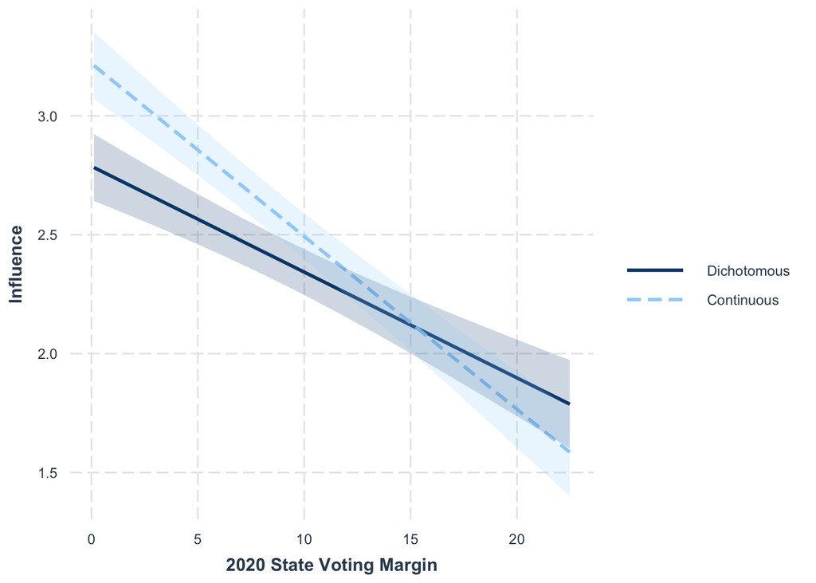

```r
ggsave("study2-margin-graph-with-rug-influence.png")
interact_plot(modInfluenceMarginGraph,pred=margin,modx=gradientC,legend.main="",x.label="2020 State Voting Margin", y.label="Influence",modx.labels=c("Continuous","Dichotomous"),interval=TRUE)
```

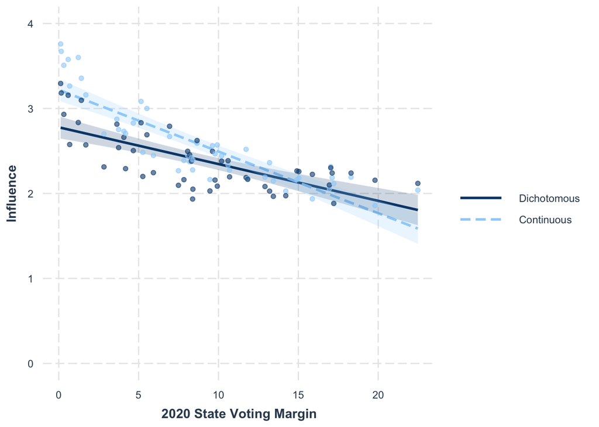

```r
ggsave("study2-margin-graph-influence.png")
# graph with points
dStates <-aggregate(d[,c("responsePolarization","influence")],by=list("state"=d$state,"gradientC"=d$gradientC,"margin"=d$margin),FUN="mean")

modInfluenceMarginGraphPts<-lmer(influence~gradientC*margin+(1|state),data=dStates)
plot <-interact_plot(modInfluenceMarginGraphPts,pred=margin,modx=gradientC,legend.main="",x.label="2020 State Voting Margin", plot.points = TRUE, y.label="Influence",modx.labels=c("Continuous","Dichotomous"),interval=TRUE)+ ylim(0,4)


plot
```

```r
ggsave("study2-margin-graph-with-points-influence.png")
```